# RFdecd: reference-free deconvolution of complex samples based on cross-cell type differential analysis

`RFdecd` is an R package for reference-free deconvolution based on feature selection. It iteratively searches for cell-type-specific features by six feature selection options, and performs composition estimation.

## 1. Installation

### Install R Dependencies

```r
# Install development tools
if (!require("remotes")) install.packages("remotes")
if (!require("devtools")) install.packages("devtools")

# Install required dependencies
install.packages(c("quadprog","corpcor"))

# Install archived RefFreeEWAS package
install.packages(
  "https://cran.r-project.org/src/contrib/Archive/RefFreeEWAS/RefFreeEWAS_2.2.tar.gz",
  repos = NULL,
  type = "source"
)
```

To install the **deconf** package successfully, follow these steps:

1. Visit the GitHub repository link: https://github.com/wwzhang-study/RFdecd/raw/main/deps/deconf_1.0.1.tar.gz (Right-click the link → “Save Link As” to download **deconf_1.0.1.tar.gz**).
2. Install from local file:

```r
install.packages(
  "PATH_TO_FILE/deconf_1.0.1.tar.gz", # Replace with your actual path
  repos = NULL,
  type = "source"
)
```

### Install RFdecd

```r
devtools::install_github(repo = "wwzhang-study/RFdecd",dependencies = TRUE,build_vignettes = TRUE,upgrade = "never")
library(RFdecd)
```

## 2. Workflow

The RFdecd workflow optimizes feature selection and composition estimation through three phases:

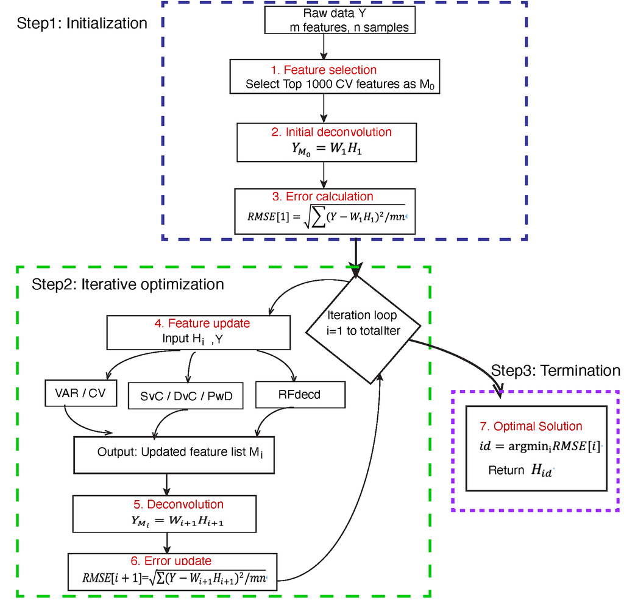

Figure 1: RFdecd Workflow

**Step 1: Initialization**

1a. **Feature Selection**: Select the top 1000 features with the largest coefficient of variation (CV) from the raw data matrix *Y*, generating a reduced matrix *Y<sub>M₀</sub>*.

1b. **Initial Deconvolution**: Perform reference-free deconvolution on *Y<sub>M₀</sub>* to estimate initial cell-type profiles (*W<sub>1</sub>*) and proportions (*H<sub>1</sub>*).

1c. **Error Calculation**: Compute the root mean squared error (RMSE[1]) between the reconstructed data (*Ŷ = W<sub>1</sub>H<sub>1</sub>*) and the original data *Y*.

**Step 2: Iterative Optimization**

For each iteration *i* (1 ≤ *i* ≤ TotalIter):

2a. **Feature Update**: Use six feature selection strategies (VAR, CV, SvC, DvC, PwD, RFdecd) to update the feature list *M<sub>i</sub>* based on current proportions *H<sub>i</sub>*.

2b. **Deconvolution**: Re-estimate profiles (*W<sub>i+1</sub>*) and proportions (*H<sub>i+1</sub>*) using the updated feature matrix *Y<sub>M<sub>i</sub></sub>*.

2c. **Error Update**: Recalculate RMSE[i+1] for the new estimates.

**Step 3: Termination**

3a. **Optimal Solution**: Select the proportion matrix *H<sub>id</sub>* corresponding to the iteration with minimal RMSE as the final output.

## 3. Example

### Gene expression example

```r
N <- 100 # Simulate a gene expression dataset with 100 samples
K <- 4 # 4 cell types
P <- 5000 # 5000 features

## Simulate proportion matrix
Hmat <- matrix(runif(N*K), ncol = K)
Hmat <- sweep(Hmat, 1, rowSums(Hmat), FUN="/")

## Simulate reference matrix
Wmat <- matrix(abs(rnorm(P*K, 4, 4)), P, K)

## Simulate mixed expression profiles
Y_raw <- Wmat %*% t(Hmat) + abs(rnorm(N*K))
rownames(Y_raw) = paste0("gene",1:nrow(Y_raw))
colnames(Y_raw) <- paste0("Sample", 1:100)

# Run RFdecd for gene expression data
res_RFdecd <- RFdeconv(DataType = "Gene expression",
                       Y_raw,
                       K,
                       CTSoption = DEVarSelect_RFdecd,
                       nMarker = 1000,
                       InitMarker = NULL,
                       TotalIter = 30)
```

### DNA methylation example

```r
N <- 100 # Simulate a DNA methylation dataset with 100 samples
K <- 4 # 4 cell types
P <- 5000 # 5000 CpG sites

## Simulate proportion matrix
Hmat <- matrix(runif(N*K), ncol = K)
Hmat <- sweep(Hmat, 1, rowSums(Hmat), FUN="/")

## Simulate reference matrix
Wmat <- matrix(rbeta(P*K,2,5), P, K)

## Simulate mixed methylation data
Y_raw <- Wmat %*% t(Hmat) + rnorm(N*K,sd = 0.1)
rownames(Y_raw) = paste0("CpG",1:nrow(Y_raw))
colnames(Y_raw) <- paste0("Sample", 1:N)

# Run RFdecd for DNA methylation data
res_RFdecd <- RFdeconv(DataType = "DNA methylation",
                       Y_raw,
                       K,
                       CTSoption = DEVarSelect_RFdecd,
                       nMarker = 1000,
                       InitMarker = NULL,
                       TotalIter = 30)
```

Parameter specifications

- **DataType (required):** Data type specification, **“Gene expression” or “DNA methylation”**.
- **Y_raw:** A raw data matrix of complex samples.
- **K:** The number of cell types.
- **CTSoption (required):** Feature selection options.

**Options:**

1. DEVarSelect_CV – Coefficient of variation;
2. DEVarSelect_VAR – Variance;
3. DEVarSelect_1VSother – Single vs. Composite (SvC);
4. DEVarSelect_2VSother – Dual vs. Composite (DvC);
5. DEVarSelect_pairwise – Pairwise Direct (PwD);
6. DEVarSelect_RFdecd – RFdecd.
- **nMarker:** Number of markers to select (default: 1000).
- **InitMarker:** Initial markers.
- **TotalIter:** Maximun iterations (default: 30).

We can have the estimated cell-type proportion matrix:

```r
head(res_RFdecd$estProp)
```

## Citation

Coming soon.